# Assignment3

Martin, Oliver and Fred

6/5/2022

We start by loading the CRSP set.

To keep the analysis simple we work with a balanced panel and exclude tickers, which are not traded for the full period.

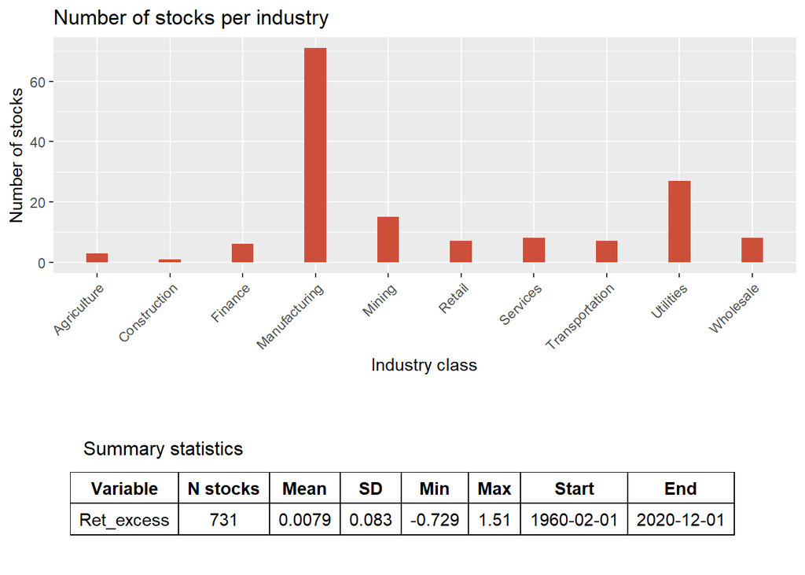

To find the optimal weight we incorporate the compute_efficient_weights function from chapter 11.4 in (Scheuss et. al 2022), where mu denotes the historical mean return, sigma is the covariance matrix, gamma is the coefficient of risk aversion (4 by prespecification), lambda is the transaction costs and w_prev is the weight before rebalancing. The function calculates the efficient portfolio weight in general form, while allowing for transaction costs. The transaction costs are conditional on the holdings before reallocation. If lamda (i.e. the transaction costs) are zero, the computation resembles the standard mean-variance efficient framework (CAPM), where the aim is to maximize the sharpe ratio.

First we calculate the return matrix, where the entire series of returns for each stock is obtained. From this it is possible to calculate the historical mean (mu) and covariance matrix (sigma).

Next we perform Ledoit-Wolf shrinkage on the variance-covariance matrix. This comes in handy, as the method serves as an effective way of overcoming issues related to var-covar matrices in large dimensions. The function is rather complex, why we refer the reader to chapter 9.2 in “Exercises for Advanced Empirical Finance: Topics and Data Science” by (Scheuss et. al 2022) for a deeper explanation.

To calculate the optimal portfolio with 1/N initial we will use the hard-coded weight parameter from the function, as this provides an initially equally-weighted portfolio.

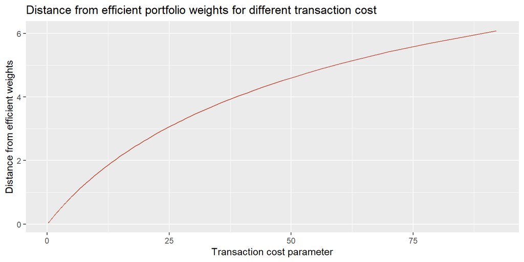

The higher the level of transaction costs, the closer will the optimal portfolio will be to the equally-weighted. Turnover penalization will make the investor reluctant towards making trades, as it is costly, and therefore choose appropriate portfolio-weights. This also makes sense as increasing transaction costs implies a higher demanded return - at some point, the costs just will not outweight the gains from the transactions, why investors will be reluctant to rebalance their portfolio.

With the helper functions, we are ready to perform the rolling-window estimation. This is done using a for loop through all the periods. Lastly, the performance is evaluated through the summarized key figures.

Summary of portfolio performance

| strategy | Mean | SD | Sharpe Ratio | Turnover |
| --- | --- | --- | --- | --- |
| MV (No SS) | 5.03 | 62.59 | 0.08 | 1.84 |
| MV (TC) | -16.46 | 163.04 | NA | 8.46 |
| Naive | 9.83 | 53.50 | 0.18 | 0.00 |

An argument for the out-of-sample experiment being “true” is that the observations used to estimate sigma (i.e., the training data) are not the one’s used for the prediction. Thus, the forecast is made using a set of un-used observations, which, by definition, makes it an out-of-sample experiment. However, the experiments aim of testing how transaction costs affects the performance by rebalancing ex ante is made using some relatively unrealistic assumptions on the structure of transaction costs as we use a standardized cost of 200 bps for all transactions. As this does not reflect the true cost structure in the market, one could argue that the results fail to present a real representation of the effect of transaction costs.